# Severe Weather Events in the US (1950–2011): Impact Analysis

NgWM with Claude AI Assistance

2025-12-26

## 1 Synopsis

This analysis examines the NOAA Storm Database to identify which types of severe weather events pose the greatest threats to population health and economic stability across the United States. The findings are intended to inform government and municipal managers responsible for preparing for severe weather events and allocating resources for emergency response and disaster mitigation.

The analysis addresses two primary questions:

1. Which types of weather events are most harmful to population health?
2. Which types of events have the greatest economic consequences?

**Key Findings:**

- Tornadoes cause the most casualties (fatalities and injuries combined)
- Floods result in the highest economic damage
- Heat-related events are a significant but often underestimated threat to public health

## 2 Data Processing

### 2.1 Data Source

The data for this analysis comes from the U.S. National Oceanic and Atmospheric Administration’s (NOAA) storm database. This database tracks characteristics of major storms and weather events in the United States, including estimates of fatalities, injuries, and property damage.

**Data URL:** https://d396qusza40orc.cloudfront.net/repdata%2Fdata%2FStormData.csv.bz2

The processed data.rds is available in https://github.com/DrNWM/Storm-Analysis

```r
# Load processed data
storm_data <- readRDS(here("data", "processed", "storm_data_processed.rds"))
summary_stats <- readRDS(here("data", "processed", "summary_statistic.rds"))

cat("Total weather events analyzed:", nrow(storm_data), "\n")
```

```
## Total weather events analyzed: 902297
```

```r
cat("Date range:", format(min(storm_data$BGN_DATE, na.rm = TRUE), "%Y"),
    "to", format(max(storm_data$BGN_DATE, na.rm = TRUE), "%Y"), "\n")
```

```
## Date range: 1950 to 2011
```

### 2.2 Data Cleaning Steps

```r
# Create summary table
data_summary <- data.frame(
  Metric = c("Total Events", "Unique Event Types", "Total Fatalities",
             "Total Injuries", "Total Economic Damage (Billions USD)"),
  Value = c(
    format(nrow(storm_data), big.mark = ","),
    length(unique(storm_data$EVTYPE_CLEAN)),
    format(sum(storm_data$FATALITIES, na.rm = TRUE), big.mark = ","),
    format(sum(storm_data$INJURIES, na.rm = TRUE), big.mark = ","),
    paste0("$", format(round(sum(storm_data$TOTAL_DAMAGE, na.rm = TRUE) / 1e9, 2),
                      big.mark = ","))
  )
)

kable(data_summary, caption = "Dataset Overview", align = c("l", "r"))
```

Dataset Overview

| Metric | Value |
| --- | --- |
| Total Events | 902,297 |
| Unique Event Types | 343 |
| Total Fatalities | 15,145 |
| Total Injuries | 140,528 |
| Total Economic Damage (Billions USD) | $477.33 |

## 3 Results

### 3.1 Question 1: Events Most Harmful to Population Health

To assess population health impact, we examined fatalities and injuries caused by different weather event types across the entire United States.

```r
health_impact <- storm_data %>%
  group_by(EVTYPE_CLEAN) %>%
  summarise(
    Fatalities = sum(FATALITIES, na.rm = TRUE),
    Injuries = sum(INJURIES, na.rm = TRUE),
    Total_Casualties = sum(TOTAL_CASUALTIES, na.rm = TRUE),
    Events = n()
  ) %>%
  filter(Total_Casualties > 0) %>%
  arrange(desc(Total_Casualties)) %>%
  slice_head(n = 15)

kable(health_impact,
      format.args = list(big.mark = ","),
      caption = "Top 15 Weather Events by Total Casualties",
      col.names = c("Event Type", "Fatalities", "Injuries", "Total Casualties", "Number of Events"))
```

Top 15 Weather Events by Total Casualties

| Event Type | Fatalities | Injuries | Total Casualties | Number of Events |
| --- | --- | --- | --- | --- |
| TORNADO | 5,661 | 91,407 | 97,068 | 60,700 |
| HIGH WIND | 1,424 | 11,498 | 12,922 | 364,869 |
| EXCESSIVE HEAT | 3,178 | 9,243 | 12,421 | 2,975 |
| FLOOD | 1,553 | 8,683 | 10,236 | 86,127 |
| WINTER STORM | 639 | 5,956 | 6,595 | 42,099 |
| LIGHTNING | 817 | 5,232 | 6,049 | 15,776 |
| WILDFIRE | 90 | 1,608 | 1,698 | 4,239 |
| HURRICANE | 135 | 1,333 | 1,468 | 299 |
| HAIL | 15 | 1,371 | 1,386 | 289,276 |
| FOG | 62 | 734 | 796 | 538 |
| RIP CURRENT | 368 | 232 | 600 | 470 |
| RIP CURRENTS | 204 | 297 | 501 | 304 |
| DUST STORM | 22 | 440 | 462 | 427 |
| TROPICAL STORM | 58 | 340 | 398 | 690 |
| AVALANCHE | 224 | 170 | 394 | 386 |

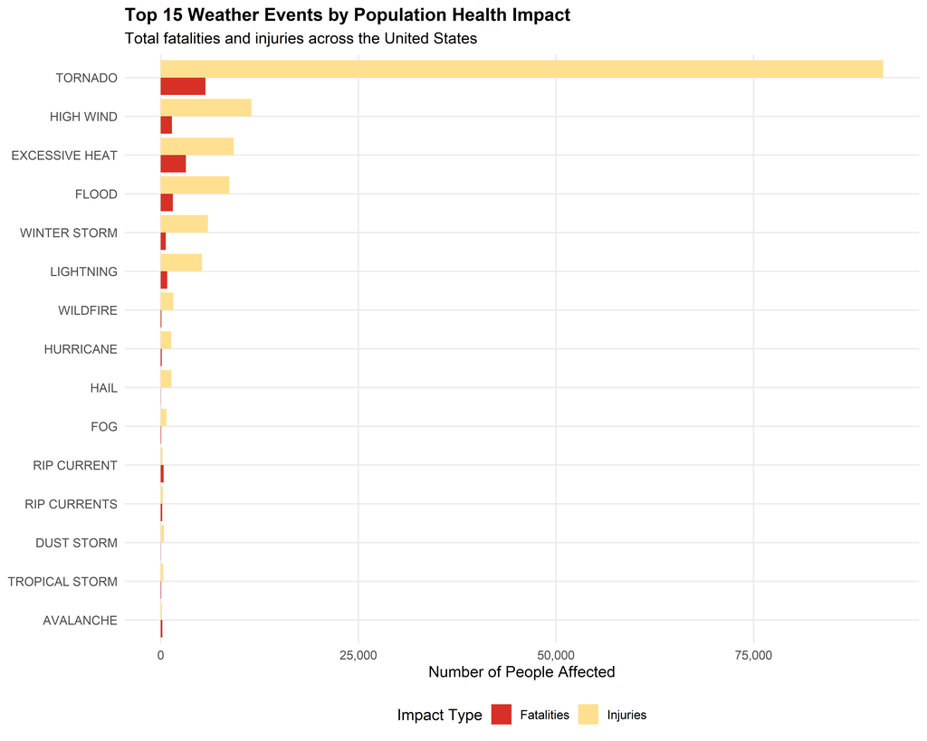

Weather events with the highest impact on population health

```r
health_impact %>%
  pivot_longer(cols = c(Fatalities, Injuries),
               names_to = "Type", values_to = "Count") %>%
  ggplot(aes(x = reorder(EVTYPE_CLEAN, Count), y = Count, fill = Type)) +
  geom_col(position = "dodge") +
  coord_flip() +
  scale_y_continuous(labels = comma) +
  scale_fill_manual(values = c("Fatalities" = "#d73027", "Injuries" = "#fee090"),
                    name = "Impact Type") +
  labs(
    title = "Top 15 Weather Events by Population Health Impact",
    subtitle = "Total fatalities and injuries across the United States",
    x = NULL,
    y = "Number of People Affected"
  ) +
  theme_minimal(base_size = 12) +
  theme(
    plot.title = element_text(face = "bold", size = 14),
    legend.position = "bottom",
    panel.grid.minor = element_blank()
  )
```

### 3.2 Question 2: Events with Greatest Economic Consequences

Economic impact was measured by combining property damage and crop damage for each event type.

```r
economic_impact <- storm_data %>%
  group_by(EVTYPE_CLEAN) %>%
  summarise(
    Property_Damage = sum(PROPERTY_DAMAGE, na.rm = TRUE),
    Crop_Damage = sum(CROP_DAMAGE, na.rm = TRUE),
    Total_Damage = sum(TOTAL_DAMAGE, na.rm = TRUE),
    Events = n()
  ) %>%
  filter(Total_Damage > 0) %>%
  arrange(desc(Total_Damage)) %>%
  slice_head(n = 15) %>%
  mutate(
    Property_Damage_B = Property_Damage / 1e9,
    Crop_Damage_B = Crop_Damage / 1e9,
    Total_Damage_B = Total_Damage / 1e9
  )

economic_table <- economic_impact %>%
  select(EVTYPE_CLEAN, Property_Damage_B, Crop_Damage_B, Total_Damage_B, Events)

kable(economic_table,
      digits = 2,
      format.args = list(big.mark = ","),
      caption = "Top 15 Weather Events by Economic Damage (Billions USD)",
      col.names = c("Event Type", "Property Damage", "Crop Damage",
                   "Total Damage", "Number of Events"))
```

Top 15 Weather Events by Economic Damage (Billions USD)

| Event Type | Property Damage | Crop Damage | Total Damage | Number of Events |
| --- | --- | --- | --- | --- |
| FLOOD | 168.27 | 12.39 | 180.66 | 86,127 |
| HURRICANE | 85.36 | 5.52 | 90.87 | 299 |
| TORNADO | 58.60 | 0.42 | 59.02 | 60,700 |
| STORM SURGE | 43.32 | 0.00 | 43.32 | 261 |
| HAIL | 15.98 | 3.05 | 19.02 | 289,276 |
| HIGH WIND | 16.24 | 2.03 | 18.28 | 364,869 |
| WINTER STORM | 12.36 | 5.31 | 17.67 | 42,099 |
| DROUGHT | 1.05 | 13.97 | 15.02 | 2,488 |
| WILDFIRE | 8.50 | 0.40 | 8.90 | 4,239 |
| TROPICAL STORM | 7.70 | 0.68 | 8.38 | 690 |
| STORM SURGE/TIDE | 4.64 | 0.00 | 4.64 | 148 |
| HEAVY RAIN/SEVERE WEATHER | 2.50 | 0.00 | 2.50 | 2 |
| HEAVY RAIN | 0.69 | 0.73 | 1.43 | 11,742 |
| EXTREME COLD | 0.07 | 1.31 | 1.38 | 657 |
| THUNDERSTORM WIND | 1.21 | 0.02 | 1.23 | 98 |

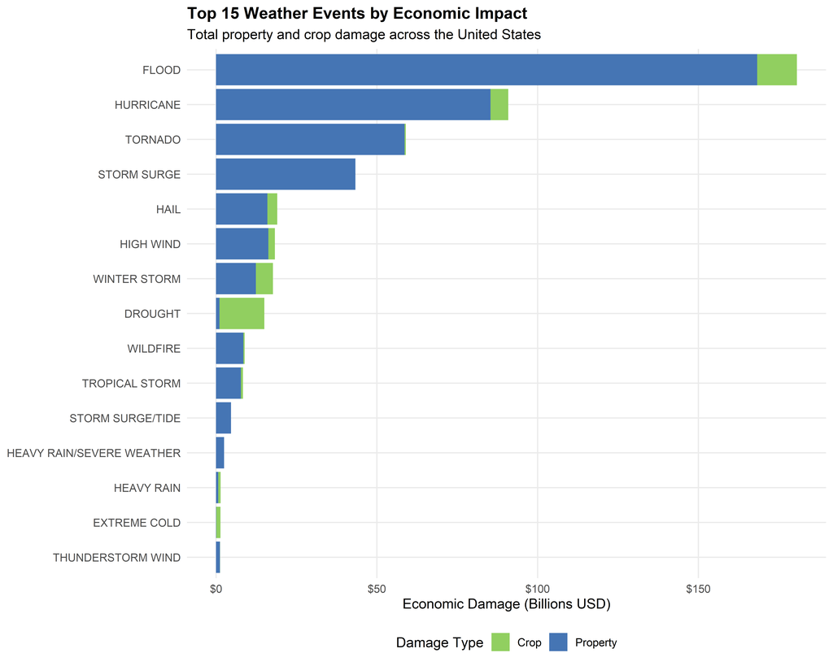

Weather events with the highest economic impact

```r
economic_impact %>%
  pivot_longer(cols = c(Property_Damage_B, Crop_Damage_B),
               names_to = "Type", values_to = "Damage") %>%
  mutate(Type = case_when(
    Type == "Property_Damage_B" ~ "Property",
    Type == "Crop_Damage_B" ~ "Crop"
  )) %>%
  ggplot(aes(x = reorder(EVTYPE_CLEAN, Damage), y = Damage, fill = Type)) +
  geom_col(position = "stack") +
  coord_flip() +
  scale_y_continuous(labels = dollar) +
  scale_fill_manual(values = c("Property" = "#4575b4", "Crop" = "#91cf60"),
                    name = "Damage Type") +
  labs(
    title = "Top 15 Weather Events by Economic Impact",
    subtitle = "Total property and crop damage across the United States",
    x = NULL,
    y = "Economic Damage (Billions USD)"
  ) +
  theme_minimal(base_size = 12) +
  theme(
    plot.title = element_text(face = "bold", size = 14),
    legend.position = "bottom",
    panel.grid.minor = element_blank()
  )
```

**Findings:**

- **Floods** cause the greatest economic damage, totaling approximately $180.7 billion
- **Hurricanes** rank second in economic impact, with damage exceeding $90.9 billion
- **Tornadoes** while most deadly, rank third in economic consequences
- **Drought** has substantial impact on agriculture, primarily through crop damage

## 4 Conclusion

This analysis reveals important distinctions between weather events that threaten population health versus those with the greatest economic impact:

**Population Health Priority:**

**Economic Damage Priority:**

1. Floods
2. Hurricanes
3. Tornadoes

**Implications for Resource Allocation:**

Heat-related events, despite their high fatality rate, may be underaddressed compared to more dramatic weather phenomena. Early warning systems and public cooling centers during heat waves could be highly cost-effective interventions.

The diverse nature of weather threats across the United States necessitates flexible, multi-hazard preparedness strategies rather than focusing resources on a single event type.

**Note:** This analysis is based on historical data and should be considered alongside current climate trends and regional risk assessments when making resource allocation decisions.